# Linear Regression Project

Jeff Wolbach

Wednesday, September 17, 2014

### Executive Summary

If one considers only a naive model of mpg vs. transmission, one can conclude that cars with manual transmissions average 7.2 mpg more than cars with automatic transmissions. However, it can be shown that essentially all of that difference is due to factors other than the type of transmission. When accounting for all relevant variables, there is no statistical dependence of mpg on transmission type.

### Analysis

The mtcars dataset contains information on fuel consumption and 10 aspects of automobile design and performance for 32 automobiles from the 1973-74 model year. One of these aspects is the type of transmission, which is encoded in the dataset as a numeric variable (am) taking a value of 0 for an automatic transmission and 1 for a manual transmission.

A boxplot can be constructed to show the variation in mpg with the type of transmission (figure A1); it is seen that cars with manual transmissions have generally higher mpg than cars with automatic transmissions. A linear regression model of mpg vs. transmission type (am) yields the equation: mpg = 17.15 + 7.24*am, where the intercept may be interpreted as the average mpg for cars with automatic transmissions (am=0) and the sum of the slope and intercept (24.39) as the average mpg for cars with manual transmissions (am=1).

However, other design aspects may be more strongly related to mpg than the type of transmission. Figure A2 displays correlation plots of mpg with the other 9 aspects of automobile design given in the dataset, and we may calculate the the correlation coefficient of each design aspect with mpg:

```
##    cyl   disp     hp   drat     wt   qsec     vs     am   gear   carb
## -0.852 -0.848 -0.776  0.681 -0.868  0.419  0.664  0.600  0.480 -0.551
```

Based on these correlation coefficients I considered five linear regression models for mpg vs. design aspects, all of which included the type of transmission. The models were:

1. mpg vs. am
2. mpg vs. am + wt
3. mpg vs. am + wt + cyl
4. mpg vs. am + wt + cyl + hp
5. mpg vs. am + wt + cyl + hp + carb

The ANOVA analysis for these five models produced:

```
## Analysis of Variance Table
##
## Model 1: mpg ~ am
## Model 2: mpg ~ am + wt
## Model 3: mpg ~ am + wt + cyl
## Model 4: mpg ~ am + wt + cyl + hp
## Model 5: mpg ~ am + wt + cyl + hp + carb
##   Res.Df RSS Df Sum of Sq     F  Pr(>F)
## 1     30 721
## 2     29 278  1       443 70.72 6.9e-09 ***
## 3     28 191  1        87 13.94 0.00093 ***
## 4     27 170  1        21  3.36 0.07813 .
## 5     26 163  1         7  1.16 0.29068
## ---
## Signif. codes:  0 '***' 0.001 '**' 0.01 '*' 0.05 '.' 0.1 ' ' 1
```

indicating that the addition of the design aspects ‘hp’ and ‘carb’ in models 4 and 5 did not produce a statistically meaningful improvement to model 3, and hence we should only consider the first three models.

In model 1:

```
##             Estimate Std. Error t value  Pr(>|t|)
## (Intercept)   17.147      1.125  15.247 1.134e-15
## am             7.245      1.764   4.106 2.850e-04
```

In model 2:

```
##             Estimate Std. Error  t value  Pr(>|t|)
## (Intercept) 37.32155     3.0546 12.21799 5.843e-13
## am          -0.02362     1.5456 -0.01528 9.879e-01
## wt          -5.35281     0.7882 -6.79081 1.867e-07
```

and in model 3:

```
##             Estimate Std. Error t value  Pr(>|t|)
## (Intercept)  39.4179     2.6415 14.9228 7.425e-15
## am            0.1765     1.3045  0.1353 8.933e-01
## wt           -3.1251     0.9109 -3.4309 1.886e-03
## cyl          -1.5102     0.4223 -3.5764 1.292e-03
```

In models 2 and 3, the coefficient on ‘am’ can not be distinguished from zero. This indicates that there is no statistical evidence that the type of transmission influences the mpg, once the weight of the vehicle is controlled for. As the coefficient on ‘cyl’ in model 3 shows statistical significance (p<0.005), we choose model 3 to be our final model. Figure A3 shows the residuals from model 3 plotted vs. the predicted mpg; the residuals are reasonably small, and show a random distribution with no obvious shape.

# Appendix

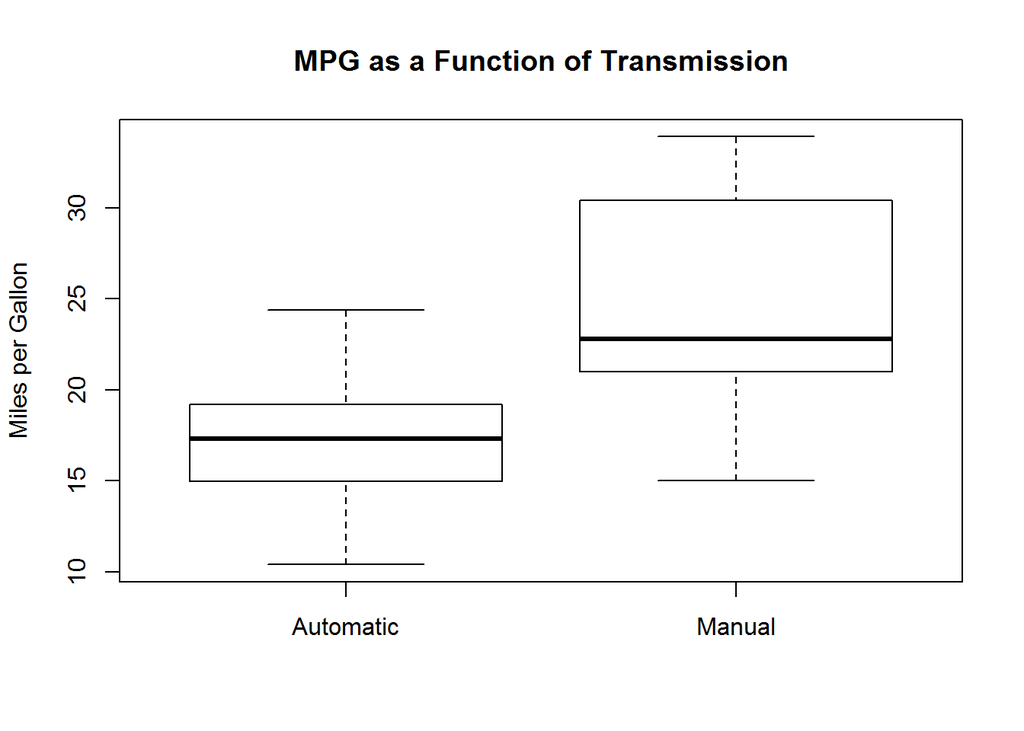

Figure A1

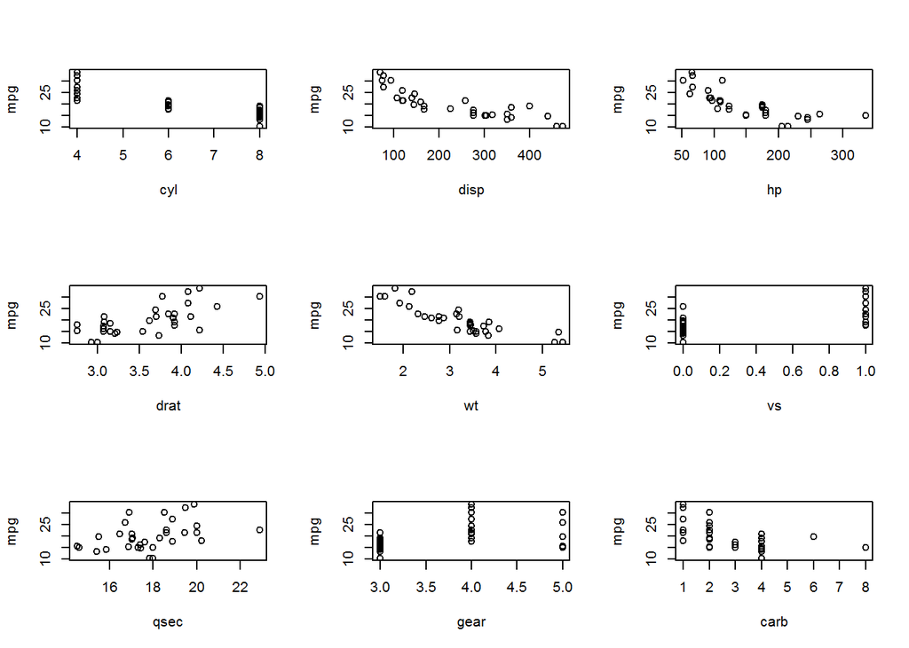

Figure A2

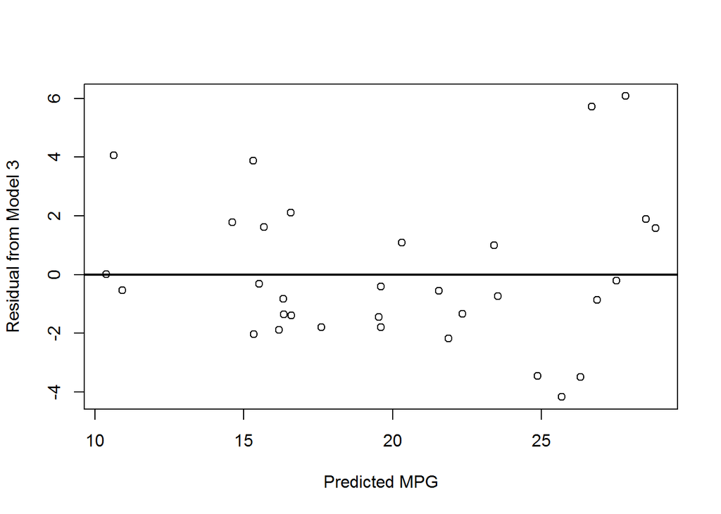

Figure A3